# MCP_counter analysis with default parameters

Rajesh Pal

2022-08-31

**The following script has been adapted from webMCP-counter R shiny app. The app currently has the following drawbacks: frequent crashes when you upload large files, and you cannot download high quality images following analysis.**

**The whole script has been written in easy to understand language. I know some of the things could have been written in a loop, or it could have been modified here and there, however i am lazy, so, feel free to do whatever you like!**

**For the analysis please use normalized data. Following analysis assumes that you have normalized counts matrix from DESEQ’s (estimatesizefactors) output. Please do not use TPM, for GOD’s sake!!**

**Provide the input directory of normalized matrix.** This code block reads the tibble data frame, converts it into dataframe and sets the first column in to row names.

```r
setwd("/omics/odcf/analysis/hipo/hipo_021/RP_all_RNAseq/rnaseq/")

normalized_matrix = read_csv("positive_matrix.csv")
normalized_matrix = as.data.frame(normalized_matrix)
rownames(normalized_matrix) <- normalized_matrix[, 1]
normalized_matrix <- normalized_matrix[,-1]
```

**Initiating MCP counter.** This code block transposes the dataframe, scale it, followed by clustering.

```r
clusterColorCode <- c("#e41a1c","#377eb8","#4daf4a","#984ea3","#ff7f00","#ffff33","#a65628","#f781bf","#999999","#8dd3c7")
names(clusterColorCode) <- paste("Cluster",1:10)

estimates <- t(data.frame(MCPcounter.estimate(normalized_matrix,featuresType = "HUGO_symbols"),check.names = FALSE))

est.norm <- t(apply(t(estimates),1,scale))
colnames(est.norm) <- row.names(estimates)

est.norm[is.na(est.norm[,1]),] <- 0

dend.mcp <- hclust(dist(est.norm,method = "euclidian"))
dend.samples <- hclust(dist(t(est.norm),method = "euclidian"))
```

**Just modify the num_of_clusters value to visualize more clusters on the heatmap or overall analysis.**

```r
##############
num_of_clusters = 3


#############
dend.samples <- color_branches(dend.samples,k=num_of_clusters,col = clusterColorCode[1:num_of_clusters])
```

**Heatmap**

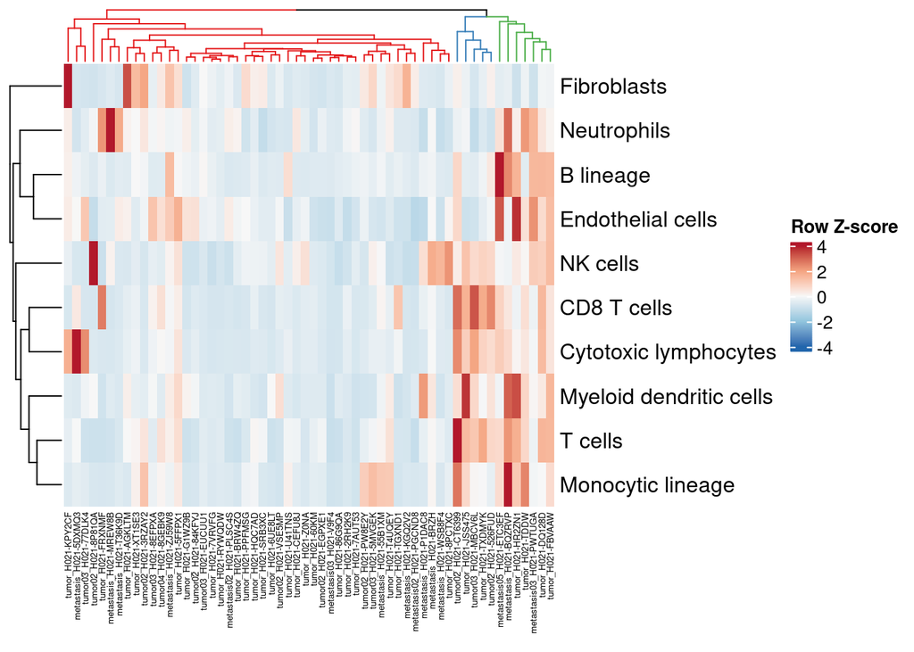

```r
###adjust col-size here
size = 5

##############################
Heatmap(as.matrix(est.norm), col = colorRamp2(c(-4,-2, 0, 2,4),c("#2166ac","#92c5de","#f7f7f7","#f4a582","#b2182b")),
        cluster_rows = dend.mcp, cluster_columns = dend.samples, show_column_names = TRUE, show_row_names = TRUE, name = "Row Z-score", column_names_gp = grid::gpar(fontsize = size))
```

**Extracting the clusters for for making boxplots/violin plots and significance analysis between the clusters.**

```r
clusters <- paste("Cluster",match(get_leaves_attr(dend.samples,"edgePar"),clusterColorCode))
clusters_n <- paste(clusters,"\n(n=",table(clusters)[clusters],")",sep="")
names(clusters_n) <- labels(dend.samples)
clusters_n <- clusters_n[rownames(estimates)]


melt_df <- function(df,var_to_group){
  df.m <- melt(df,id = var_to_group,varnames = c("variable","value"))
  colnames(df.m)[1] <- "groups"
  df.m$value <- as.numeric(as.character(df.m$value))
  return(df.m)
}

# get boxplots
estimates_df <- data.frame(estimates,check.names = F)
estimates_df$clusters <- clusters_n
melted_est <- melt_df(estimates_df,var_to_group = 'clusters')
```

**Initiating violin plots with significance test between all the groups. At present it performs t-test, Need to modify the code if you want to perform any other test. BTW, the worst code block begins!! Please don’t judge me, and i wont judge you!**

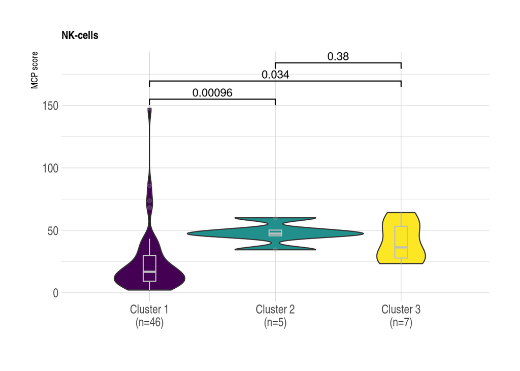

[figure not shown]

[figure not shown]

[figure not shown]

[figure not shown]

[figure not shown]

[figure not shown]

[figure not shown]

[figure not shown]

[figure not shown]

```r
melted_est%>%
  filter(variable == "NK cells") %>%
  select(groups,value) %>%
  #left_join(sample_size) %>%
  mutate(myaxis = groups) %>%
  {ggplot(.,aes(myaxis, value, fill= groups)) +
      geom_violin(width=1.4) +    #    ggbeeswarm::geom_beeswarm()+
      geom_boxplot(width=0.1, color="grey", alpha=0.2) +
      scale_fill_viridis(discrete = TRUE) +
      theme_ipsum() +
      theme(
        legend.position="none",
        plot.title = element_text(size=11)
      ) +
      ggtitle("NK-cells") +
      xlab("") + ylab("MCP score") +
      ggsignif::geom_signif(comparisons =  combn(sort(unique(.$groups)),2,  simplify = F),
                            step_increase = 0.1,test='t.test')}
```

In case you wanted simple box plots, here it is! Not that fancy right?

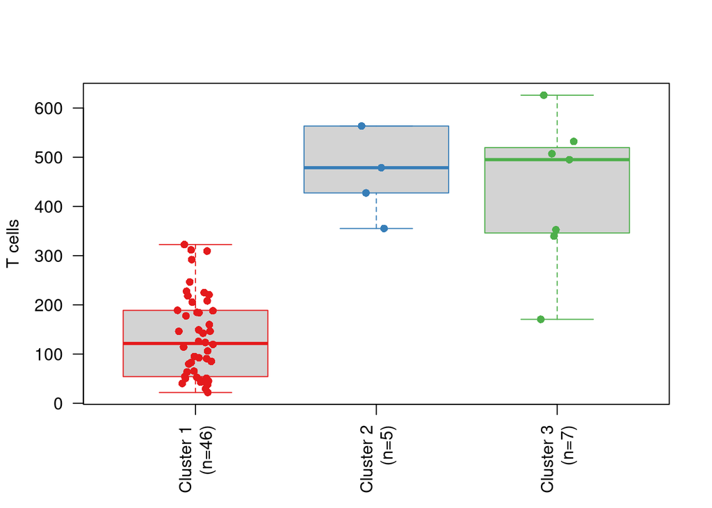

```r
boxplot(estimates[,"T cells"]~clusters_n,xlab = "", ylab = "T cells", border = clusterColorCode,outline=FALSE, las=2)
stripchart(estimates[,"T cells"]~clusters_n,vertical = TRUE, add=TRUE, method = "jitter",pch=16, col = clusterColorCode)
```